# Identify recurrent cluster features

# Summary figures

`recurrent_patterns/plots/recurrent_patterns_summary.pdf` (from 01), four pages: the six family profiles (step 5), family prevalence and mean read fraction per gene group (step 8), gene group mean m6A and nucleosome profiles (step 9), silhouettes for k = 2..8 and core m6A vs core nucleosome per cluster

`recurrent_patterns/plots/03_cluster_gene_summary.pdf` (from `03_cluster_gene_summary.R`), four pages: family profiles of the five signals, gene group profiles, occluded-TSS fiber fraction per gene group, and archetype profiles

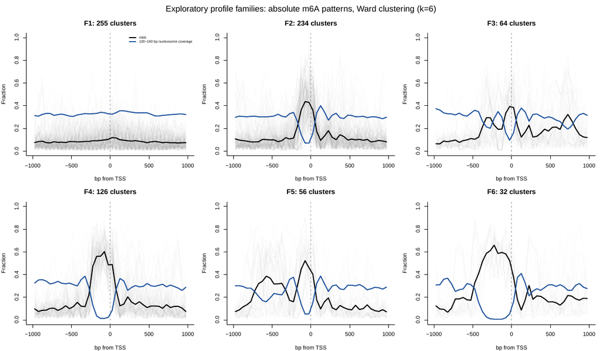

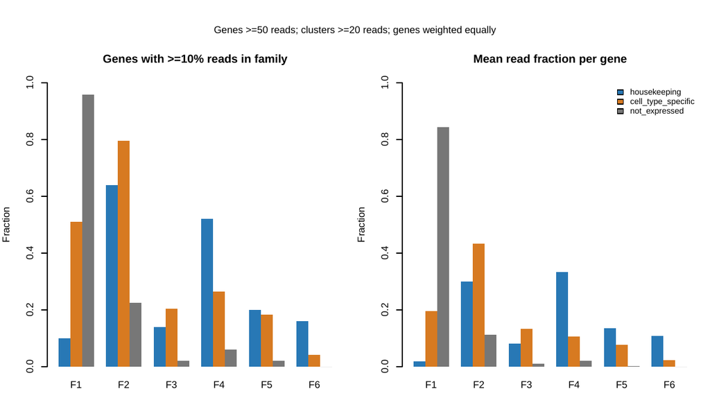

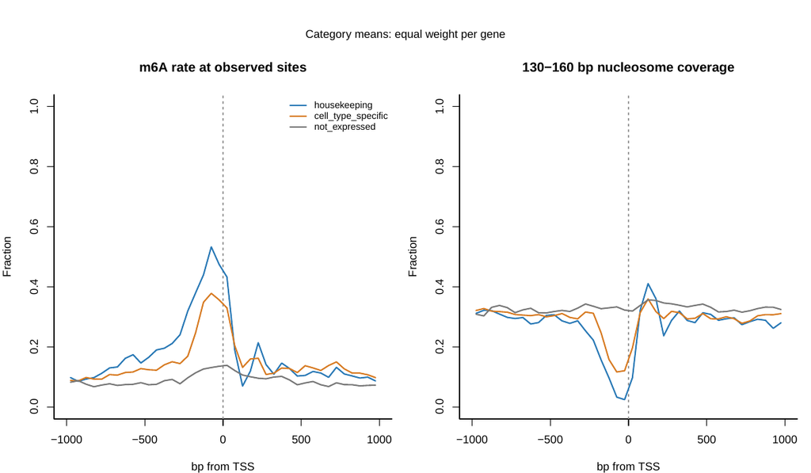

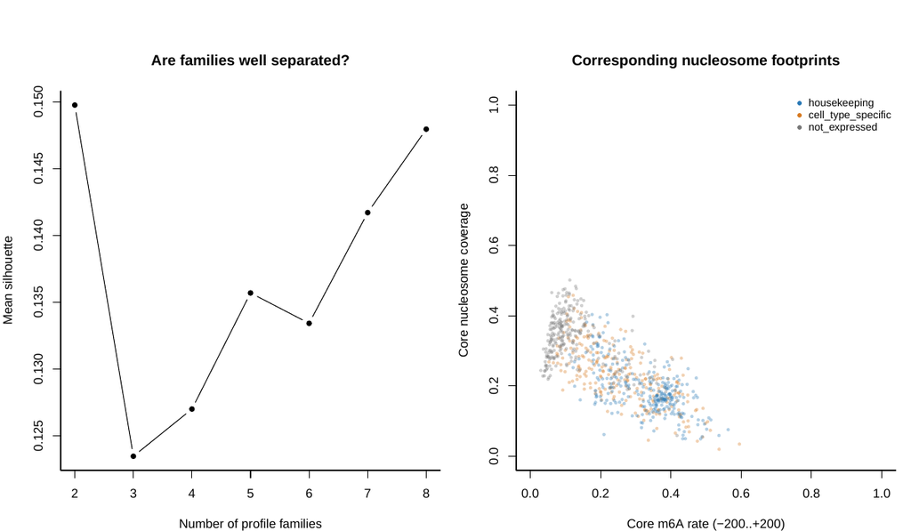

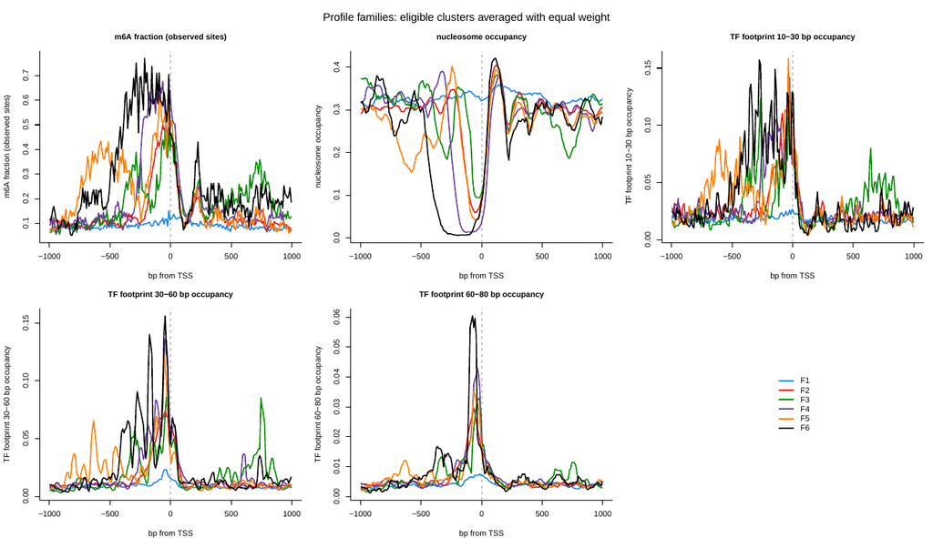

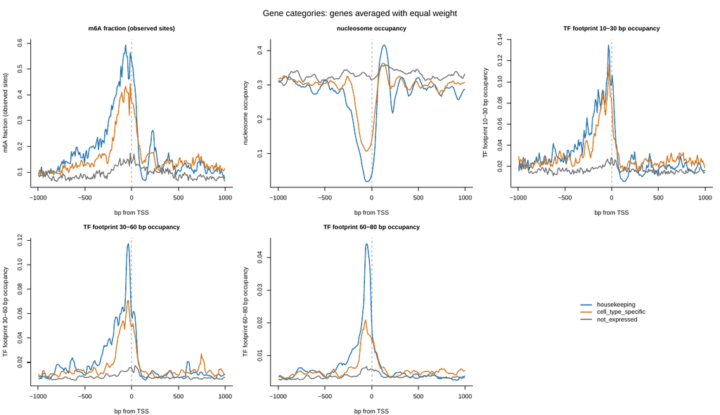

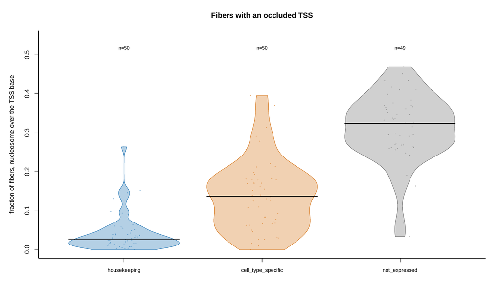

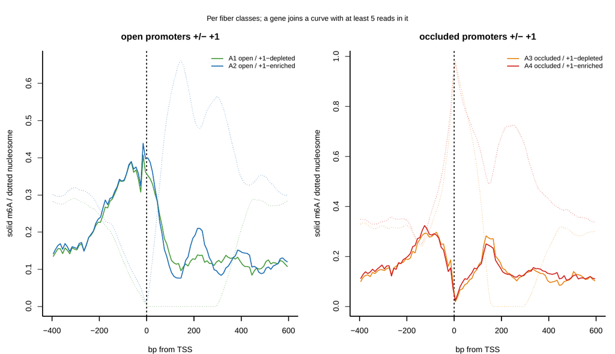

```r
summary_plot_dir <- file.path(OUT_DIR, "recurrent_patterns/plots")
knitr::include_graphics(unlist(lapply(
  file.path(summary_plot_dir, c("recurrent_patterns_summary.pdf", "03_cluster_gene_summary.pdf")),
  show_pdf_pages)))
```

# Puffin for promoter annotations

`/project/spott/cshan/fiber-seq/code/pausing/PolII/promoter_annotation/04a_puffin_motif_scores.py` asks which promoter motif contributes most to transcription start at each example gene’s TSS. It uses Puffin (Dudnyk et al., 2024), a deep-learning model that predicts TSS activity from DNA sequence alone. Puffin also breaks each prediction into the contributions of individual motifs (TATA, YY1, SP, ETS, NFY, CREB, NRF1, ZNF143, U1 snRNP), plus initiator and trinucleotide effects

1. load the genes used for clustering
2. get the sequence for each gene, for each gene it cuts 1,650 bp of hg38 centred on the TSS the fiber analysis used (TSS +/- 825 bp)
3. run puffin using `net.interpret(seq, "FANTOM_CAGE")` –> per-base tracks over TSS −500 to +499. These are the predicted TSS signal (the CAGE-like prediction), each motif’s effect, and the summed motif, initiator, trinucleotide and total effects
4. score gene motif at the TSS by taking the 20 bp around the TSS (−10 to +9). It averages each motif’s effect over those bases, weighting each base by Puffin’s predicted TSS signal there –> This gives one number per motif per gene. Bases where Puffin predicts initiation count most
5. find the TATA box by searching the TATA+ motif activation track between −60 and −10 bp. The peak position is tata_center and its height is tata_activation
6. label ach gene by its strongest motif. Among the 14 motif scores, excluding U1 snRNP, the largest is dominant_motif_excl_U1, and its value is dominant_contribution_excl_U1

one row per gene, with every motif score, the summed effects, the TATA position and activation, and the dominant-motif label

- the position of the motif is inferred from puffin predicted motif center, and I chose the motif span based on the length of the consensus sequence (TATA box: TATAWAWR - 8bp, YY1 - AAGTAGGCGG - 10bp)

```r
puffin_root <- "/project/spott/cshan/fiber-seq/LCL_project/pausing/PolII/promoter_annotation/tables"
motif_score <- read.delim(file.path(puffin_root, "04a_puffin_motif_scores.tsv"))
head(motif_score)
```

```
##   gene_name chrom puffin_tss0 strand  TATA..   YY1..    SP.. SP...1  ETS..
## 1      CD74  chr5   150412750      -  1.2616  0.0260  0.7082 0.0668 0.1592
## 2   HLA-DRA  chr6    32439886      +  0.1362  0.0933 -0.0129 0.0687 0.0495
## 3  HLA-DRB1  chr6    32589804      -  0.3786  0.0455 -0.0034 0.0881 0.3804
## 4  HLA-DQA1  chr6    32637405      + -0.0032 -0.0030 -0.0068 0.0757 0.0884
## 5      IRF4  chr6      391751      +  1.2070  0.0057 -0.3526 2.6957 0.1819
## 6  HLA-DPB1  chr6    33075989      +  0.1390  0.0133 -0.1006 0.0137 0.0882
##   ETS...1  NFY.. NFY...1  CREB.. CREB...1  NRF1.. NRF1...1 ZNF143.. ZNF143...1
## 1 -0.0369 1.0914  0.0063 -0.0218  -0.0023 -0.1160  -0.2373  -0.0002    -0.0104
## 2 -0.0155 0.1719  1.6509  0.0171   0.1403 -0.0028  -0.0003   0.0006    -0.0012
## 3  0.2758 0.1072  1.2590  0.0239   0.1878 -0.0026  -0.0059  -0.0007     0.0000
## 4 -0.0176 0.0046  1.0500  0.2462   0.0450 -0.0037   0.0000  -0.0001    -0.0001
## 5  0.0024 0.0463  0.0033  0.0293  -0.0027  0.0024   0.0019   0.0358    -0.0012
## 6  0.0088 0.8622  0.8298  0.0087  -0.0341  0.0003  -0.0001   0.0012    -0.0004
##   U1.snRNP.. total_effect_tss motif_effect_tss initiator_effect_tss
```

[output cut: 27 more lines]

one row per gene per position from −500 to +499

```r
motif_effect <- read.delim(file.path(puffin_root, "04a_puffin_effect_profiles.tsv.gz"))
head(motif_effect)
```

```
##   gene_name              group position   total   motif initiator trinucleotide
## 1      CD74 cell_type_specific     -500 -0.8743 -0.5720   -1.1831        0.9271
## 2      CD74 cell_type_specific     -499 -0.7782 -0.5834   -1.1036        0.9602
## 3      CD74 cell_type_specific     -498 -0.8363 -0.5844   -1.1379        0.9456
## 4      CD74 cell_type_specific     -497 -0.8866 -0.5745   -1.2635        1.0145
## 5      CD74 cell_type_specific     -496 -0.8249 -0.5606   -1.2090        1.0096
## 6      CD74 cell_type_specific     -495 -0.5671 -0.5465   -1.0474        1.0945
```

## TATA promoters on single molecules: SRSF3, NFKBIA, CR2, SPIB

TATA-class genes with the strongest drop in m6A and the strongest 10-30 bp footprint at their own TATA box (TATA box bin vs the bins 30-60 bp around it). The read level figure of `plot_read_level()` (as in `plots/example_reads/<group>/<gene>/read_level_plots`: TSS +/- 1 kb, reads ordered by +1 nucleosome start, all nucleosomes and 10-80 bp TF footprints) with a TATA box panel, the Pol II ChIP track, the m6A fraction of all reads and the TATA box (Puffin `tata_center` +/- 4 bp) shaded yellow. PDFs are saved under `promoter_annotation/plots/TATA_motif_read_examples/`.

```r
TATA_GENES <- c("SRSF3", "NFKBIA", "CR2", "SPIB")
TATA_MOLECULE_DIR <- file.path(OUT_DIR, "promoter_annotation/plots/TATA_motif_read_examples")

# TSS, strand and Puffin TATA box and YY1 site centres of one gene
tata_gene <- function(gene) {
  gf <- fread(file.path(OUT_DIR, "read_features/tables/gene_features.tsv"))[gene_name == gene]
  pf <- fread(file.path(OUT_DIR, "promoter_annotation/tables/04a_puffin_motif_scores.tsv"))[gene_name == gene]
  stopifnot(nrow(gf) == 1L, nrow(pf) == 1L)
  cbind(gf[, .(group, gene_name, chrom, tss, strand, tss_source)], pf[, .(tata_center, yy1_center)])
}

# read level figure of one gene: the reads, footprints and read order of plot_curated_gene(), with
# the Puffin motif centre `center` (column of tata_gene()) shaded and labelled `label`
plot_tata_read_level <- function(gene, center = "tata_center", label = "TATA box",
                                 out_dir = TATA_MOLECULE_DIR, suffix = "tata") {
  g <- tata_gene(gene)
  region <- data.frame(region_id = g$gene_name, chr = g$chrom,
    start = g$tss + EXAMPLE_RANGE[1] - 1L, end = g$tss + EXAMPLE_RANGE[2],
    analysis_start = g$tss + EXAMPLE_RANGE[1], analysis_end = g$tss + EXAMPLE_RANGE[2])
  samples <- fread(SAMPLES)[, .(sample_name, fire_dir)]
  dat <- assemble_region_m6a(as.data.frame(samples), region, full_span = TRUE,
    positions = seq(region$analysis_start, region$analysis_end))
  meta <- dat$rids_df
  plain <- meta$RID[order(match(meta$sample_name, samples$sample_name), meta$start, meta$RID)]
  plot_read_level(g, example_footprints(g, dat), plain,
                  file.path(out_dir, paste0(gene, "_", suffix, "_read_level.pdf")),
                  met_mat = dat$met_mat, tata_center = g[[center]], motif_label = label)
}
```

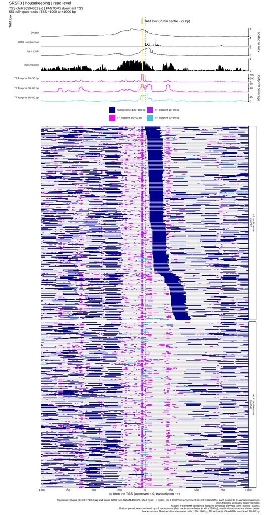

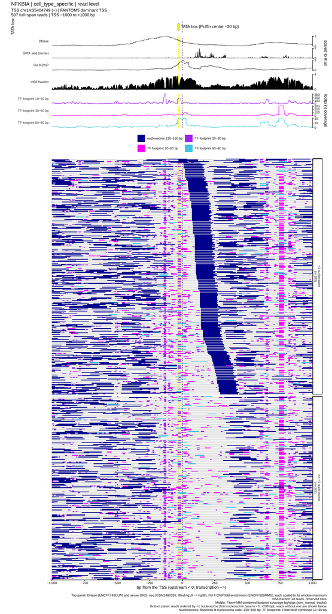

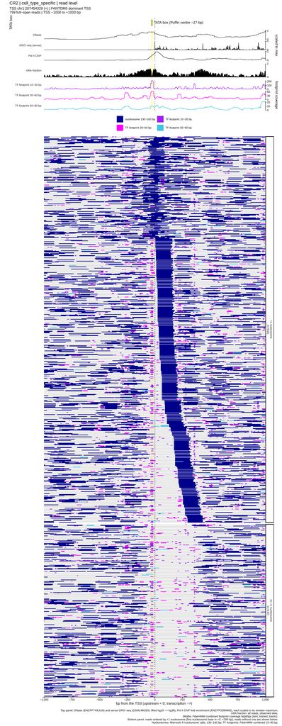

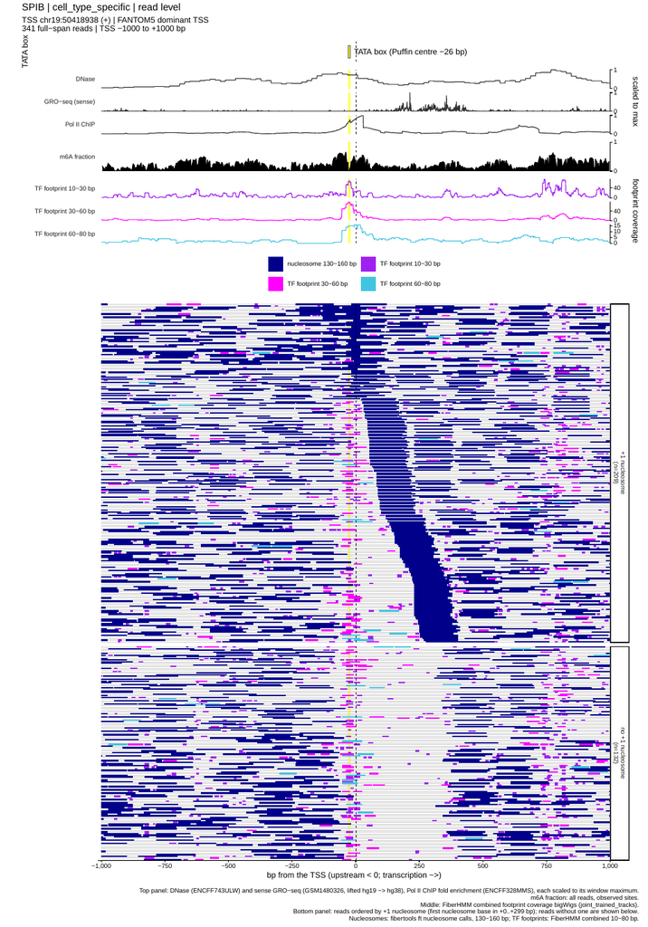

```r
tata_pdfs <- vapply(TATA_GENES, plot_tata_read_level, character(1))
knitr::include_graphics(unlist(lapply(tata_pdfs, show_pdf_pages)))
```

### Motif and nucleosome and footprint occupancy features

Genes are grouped by their Puffin dominant motif (`group_excl_U1` of 04a)

`puffin_motif_class_plus1_density.pdf`: the +1 start of every read with an accessible TSS (`plus1_start`, the first nucleosome start within +0..+299 bp), for motifs with >= 5 genes and genes with >= 10 such reads. Each gene gets the same total weight, so deeply covered genes do not dominate a motif’s density. The dashed line is the median of the motif’s per-gene median +1 start

Each line is the mean (+/- se) of the per-gene 10 bp bin profiles of over the motif’s genes (TSS +/- 500 bp, oriented by strand), and the grey line is the mean over all other genes

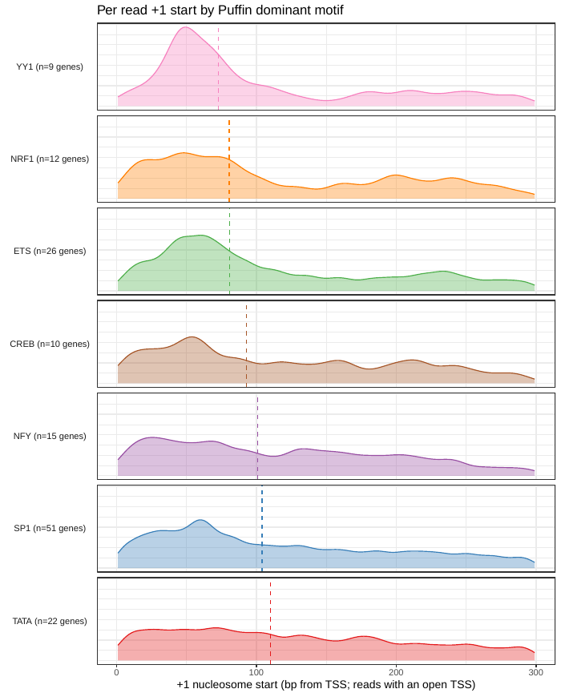

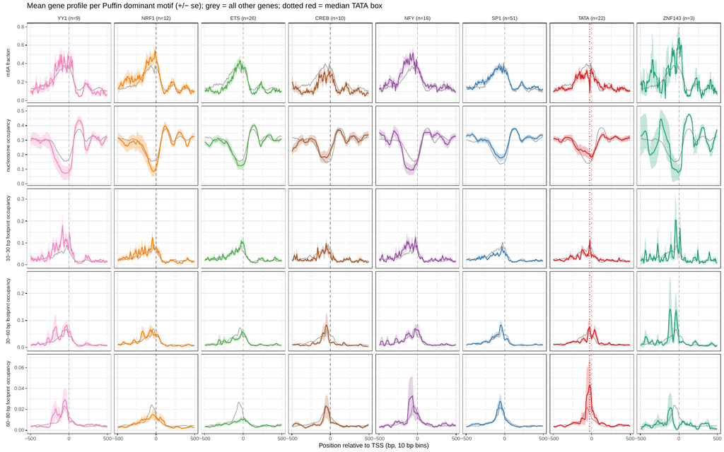

```r
motif_plot_dir <- file.path(OUT_DIR, "promoter_annotation/plots")
knitr::include_graphics(unlist(lapply(
  file.path(motif_plot_dir, c("puffin_motif_class_plus1_density.pdf", "puffin_motif_smf_features.pdf")),
  show_pdf_pages)))
```

TSS used for puffin is fantom5 dominant TSS for each gene, it this is not present for the selected gene, then the gencode canonical TSS is used

## YY1 promoters on single molecules: SPCS2, NDUFA9, EIF3E, RPS11, ATP5PO

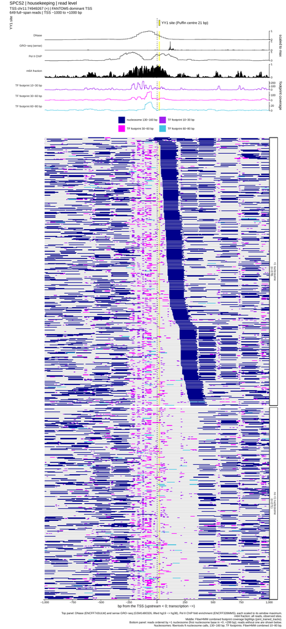

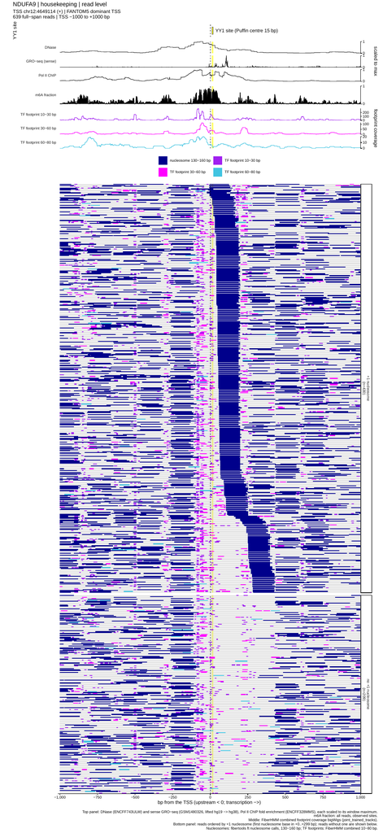

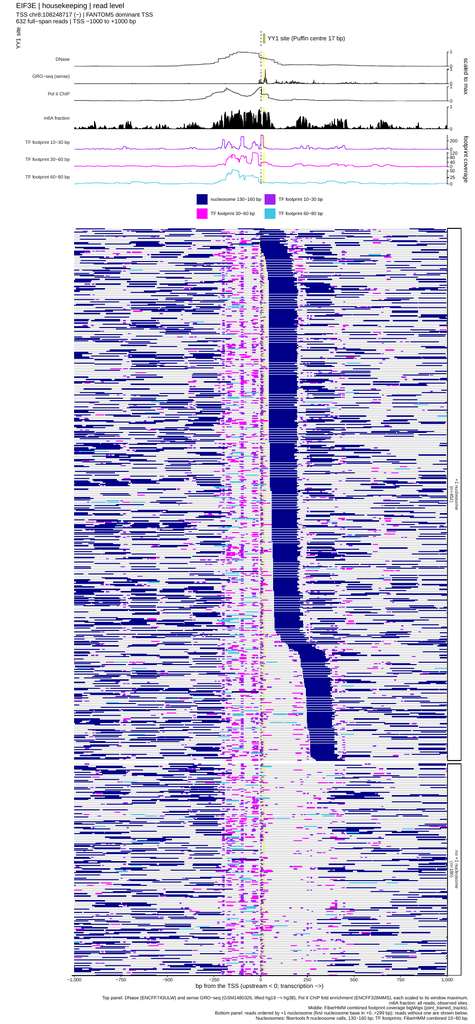

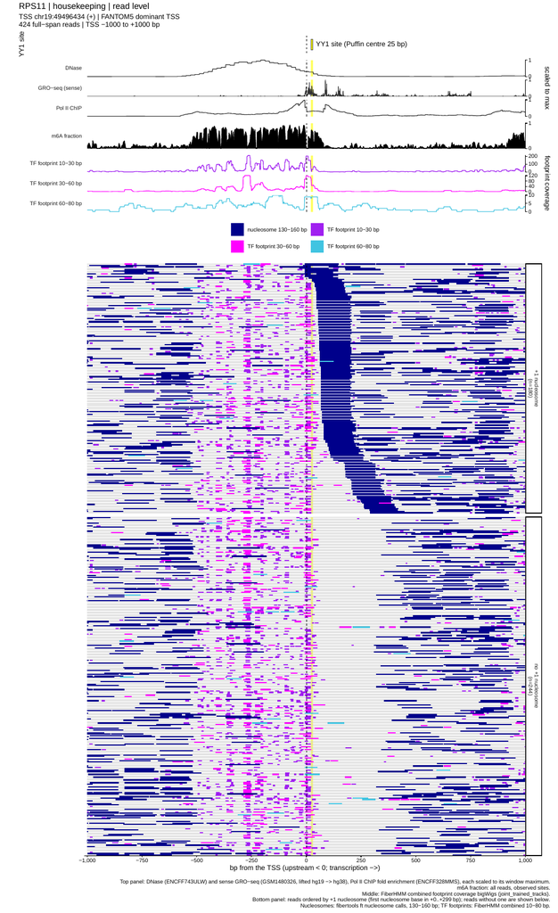

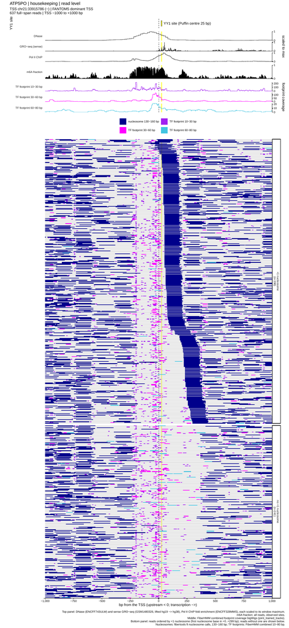

```r
YY1_GENES <- c("SPCS2", "NDUFA9", "EIF3E", "RPS11", "ATP5PO")
YY1_MOLECULE_DIR <- file.path(OUT_DIR, "promoter_annotation/plots/YY1_motif_read_examples")
dir.create(YY1_MOLECULE_DIR, recursive = TRUE, showWarnings = FALSE)
yy1_pdfs <- vapply(YY1_GENES, plot_tata_read_level, character(1), center = "yy1_center",
                   label = "YY1 site", out_dir = YY1_MOLECULE_DIR, suffix = "yy1")
knitr::include_graphics(unlist(lapply(yy1_pdfs, show_pdf_pages)))
```

# Promoter QTLs from Einarsson et al., 2022

**they proposed that “Alternative TSSs of low variability promoters indicate a novel mechanism of mutational robustness”**

eQTLs are rarely found at housekeeping or ubiquitous genes and have limited effects when present, possibly due to selection or robustness mechanisms - flexible TSS architecture could mask variant effects on individual core promoters.

1. **Promoter eQTLs (prQTLs)** Testing common SNPs (MAF ≥ 10%, within 25 kb) found 2,457 promoters with >= 1 prQTL (5% FDR), more often at highly variable promoters. Fewer common variants lie near low-variable promoters, suggesting negative selection, and lead-SNP effect size correlates with variability
2. **Decomposed promoter eQTLs (dprQTLs)** dprQTLs show similar prevalence and maximum effect sizes across variability classes, indicating that flexible TSS architecture limits how variant effects on individual core promoters propagate to total promoter output
3. **Fraction QTLs (frQTLs)** Testing association with each decomposed promoter’s fractional contribution to its parent found 1,230 promoters with >=1 frQTL. Unlike prQTLs and dprQTLs, frQTLs are more common in low-variable promoters

#### Single molecules at the RGS14 and GGNBP2 promoter QTLs

1. Partial shift example: RGS14
- SNP rs56235845 (chr5:177371039 T/G) affects contributions of decomposed promoters 1 and 2 and still has a noticeable effect on total promoter activity
2. Compensatory switch example: GGNBP2
   - SNP rs9906189 (chr17:36549567 G/A) shifts the two decomposed promoters in opposite directions, yet total output is essentially unchanged

m6A molecules of the 27 phased LCL samples spanning SNP +/- 1 kb, split by donor VCF genotype and, in heterozygous donors, by the base each read carries at the SNP

```r
QTL_DIR <- file.path(OUT_DIR, "promoter_annotation/plots/promoter_qtl_examples_Einarsson")
qtl_config <- list(root = file.path(PROJECT, "LCL_project/co-accessibility/CRE_co-accessibility_FIRE"),
  fire_root = file.path(SHARED, "FIRE/results"), tabix = "/project/spott/cshan/envs/dimelo/bin/tabix",
  code_root = file.path(PROJECT, "code"), locus_flank_bp = 1000L)
qtl_gene_models <- load_canonical_gene_models("/project/spott/cshan/annotations/gencode.v46.annotation.gtf.gz")
qtl_snps <- data.frame(gene = c("RGS14", "GGNBP2"), snp_id = c("rs56235845", "rs9906189"),
  chrom = c("chr5", "chr17"), pos = c(177371039L, 36549567L), ref = c("T", "G"), alt = c("G", "A"))
qtl_examples <- lapply(seq_len(nrow(qtl_snps)), function(i) with(qtl_snps[i, ],
  plot_snp_genotype_molecules(chrom, pos, ref, alt, snp_id, gene, QTL_DIR,
    config = qtl_config, models = qtl_gene_models, profile_bars = TRUE)))
knitr::kable(rbindlist(lapply(qtl_examples, function(x)
  x$group_sizes[, .(SNP = x$region$focal_snp, group = cluster, molecules, samples, donors)])))
```

| SNP | group | molecules | samples | donors |
| --- | --- | --- | --- | --- |
| rs56235845 | TT | 37 | 2 | 2 |
| rs56235845 | TG: T reads | 74 | 9 | 9 |
| rs56235845 | TG: G reads | 67 | 10 | 10 |
| rs56235845 | GG | 171 | 14 | 14 |
| rs9906189 | GG | 31 | 4 | 4 |
| rs9906189 | GA: G reads | 75 | 14 | 14 |
| rs9906189 | GA: A reads | 66 | 13 | 13 |
| rs9906189 | AA | 80 | 9 | 9 |

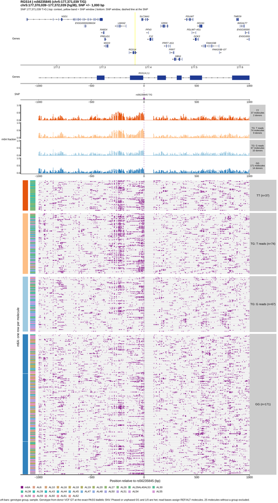

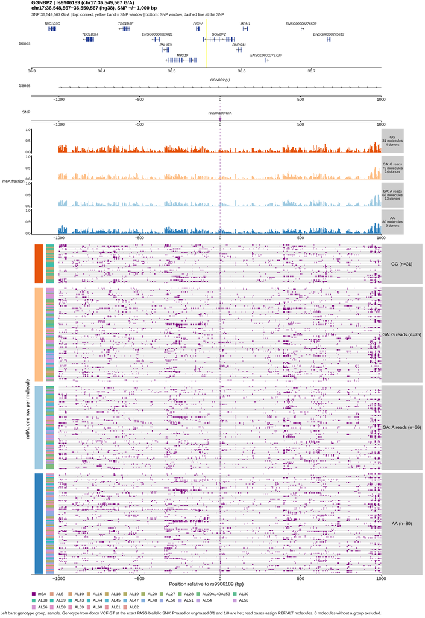

```r
knitr::include_graphics(unlist(lapply(qtl_examples, function(x) show_pdf_pages(x$file))))
```